# GEOG458_Lab2

### Please create a narrative based on your research. In your narrative, please describe the topic as well as the parameters you have used for search (5 PTS)

In the realm of urban development and dynamic landscapes of cities, the merging concepts like urbanization and new urbanism shapes the future of our urban future. My analysis begun by looking deeper into urban development to understand the ever-evolving dynamics of cities. I honed in on the the following keywords “urban development”, “urbanization”, and “new urbanism”. These terms became the compass guiding my exploration into the conplexities of city planning, design, and emerging concept of urban living. My search parameters focused on the importance of these keywords in discussions surrounding videos abut urban development. By using a word frequency analysis show key themes, with top words like “Urban”, “city”, “plan”, “develop”, “future”, and “new” shaping the narrative. These words formed the backbone of this search, representing the fundamental elements that are contributing to the urban landscape.

### why do you want to make this comparison (5 PTS)

The decision to make this comparison between “urban development”, “urbanization”, and “new urbanism” comes from recognizing that they all have different perspectives and pathways of addressing urban challenges. Urban development has a historical context and has evolved over centuries, urbanization represents a demographic trend that has been ongoing for centuries and new urbanism is a response coming from challenges posed by conventional urban development. These three key words show a different perspective to the transformative nature of cities. These tree key words also address urban challenges, urban develop focuses on the challenges of infrastructure, housing, and economic growth. While urbanization raises questions about the rising population and new urbanism wants to address the issues that relate to the environment.

### how your research could be improved in the future (5 PTS)

This research could be improved for the future by inviting stakeholder perspectives, by incorporating a diverse range of stakeholders such as city planners, residents and community leaders this will provide a well rounded view of those impacted by urban development initiatives. This also can be a temporal analysis to see how urbanization trends and planning have changed over time. This could also be a comparative global analysis, looking how different countries and regions implement urban policies and adapt to unique socio-economic and cultural contexts.

### anything you find from the map or data that is different from your expectation before the exercise, or anything that stands out to you (5 PTS)

Something that stood out to me was the word “future”, as city’s and planners are always looking forward in terms of urban development and anticipating what lies ahead. With the combination of “new” and “urbanism” emphasizes the transformative nature to city planning.

[first csv](https://github.com/mykenzieh03/GEOG458_Lab2/blob/f7477b10a652c9b7a0a89f11d1f71a6ef45d0a86/search-result-1.csv)

[second csv](https://github.com/mykenzieh03/GEOG458_Lab2/blob/f7477b10a652c9b7a0a89f11d1f71a6ef45d0a86/search-result-2.csv)

[third csv](https://github.com/mykenzieh03/GEOG458_Lab2/blob/f7477b10a652c9b7a0a89f11d1f71a6ef45d0a86/search-result-3.csv)

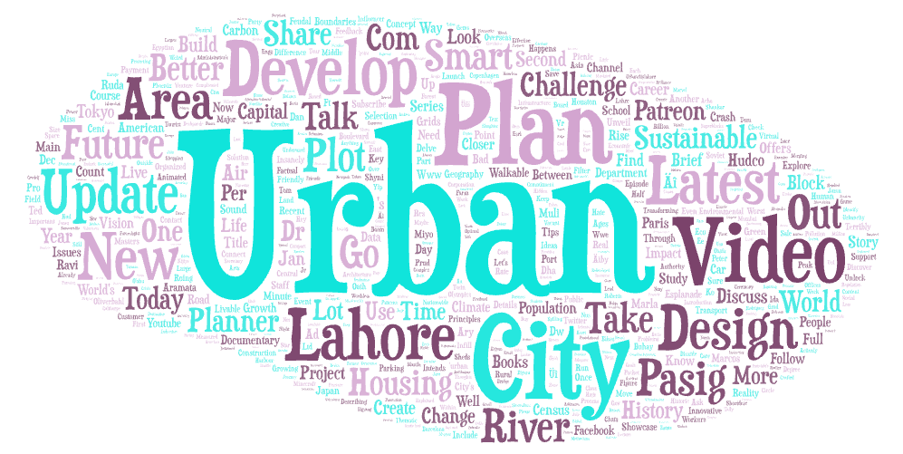

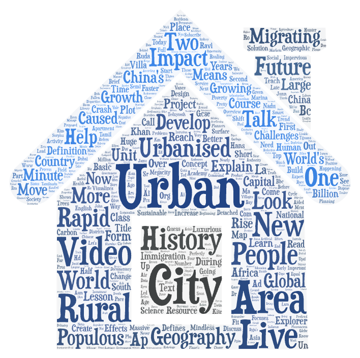

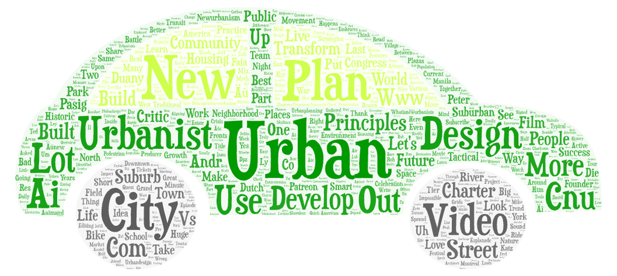